# City_Rent_Markdown

Thomas Friss

February 9, 2019

## City Rent R Markdown document

Here are the packages I have loaded from the library and the first dataset that I import into the script. The CSV file contains median rents over time for different cities across the US

```r
library(dplyr)
```

```r
library(ggplot2)
library(tidyverse)
full_rent_df <- read.csv("City_MedianRentalPrice_AllHomes.csv", stringsAsFactors =FALSE)
```

After this I created a vector that had the names of the cities I wanted to analyze. This list does not include New York City because there is no single New York City in this dataset but a metropolitan area called New York.

```r
city_list <- c("San Francisco","Boston", "Chicago","Los Angeles", "Washington",
               "Seattle","Atlanta", "Austin", "Raleigh", "Durham", "Philadelphia",
               "Dallas", "Denver", "Detroit", "Minneapolis", "Saint Paul", "San Diego",
               "Houston")
```

Here is what I used to find the areas in the New York metropolitan area. I do not know why I had to use grepl or even if I did but I remember grep not working properly and I am still not entirely sure why. I saved this into a different object and will rbind() it to another dataframe later.

```r
new_york_rent <- full_rent_df %>% filter(grepl("New York", full_rent_df$Metro))
```

Finding which rows in the dataset match the cities I want to look at.

```r
rent_tibble <- full_rent_df %>% filter(RegionName  %in% city_list)
```

Next is a series of code provided by Blaine Bateman, a mentor at Springboard. This was in response to me having difficulties with creating graphs to visualize my data.

I will copy the instructors description of his code because he can explain it better then I can.

The following uses:

1. filter to get Chicago, then
2. the select is from dplyr to choose columns, and I take advantage of the fact that the years are all 20xx,
3. using the colnames() function to get the names, the
4. substr() function to get the 2nd & 3rd characters,
5. and the == “20” to choose only those that have the years in them.
6. The t() function is “transpose”, which converts from a row to a column,
7. as.data.frame() is handy to keep some functions happy that don’t like matrices etc.,
8. rename() puts a name on the column so it is easier to use later in ggplot, using
9. names(.) to refer to the current (empty) column names,
10. and the mutate creates an x-value (time) using just the row number (the row() function) as a sequence of quarter numbers.

```r
 chicago_ts <-
    full_rent_df %>%
    filter(substr(RegionName, 1, 7) == "Chicago") %>%
    select(which(substr(colnames(.), 2, 3) == "20")) %>%
    t(.) %>%
    as.data.frame() %>%
    rename(rent = names(.)[1]) %>%
    mutate(time_qtr = row(.))
```

Next I did some modeling and visualization.

For some of the statistical graphs I am still not entirely sure what all of them mean but I will have to look them up in the future.

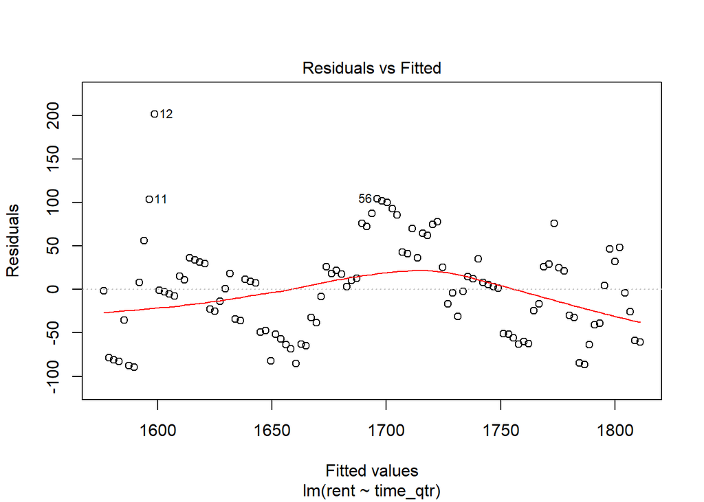

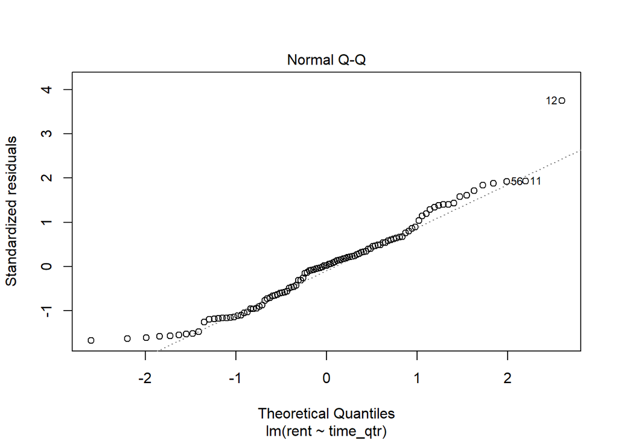

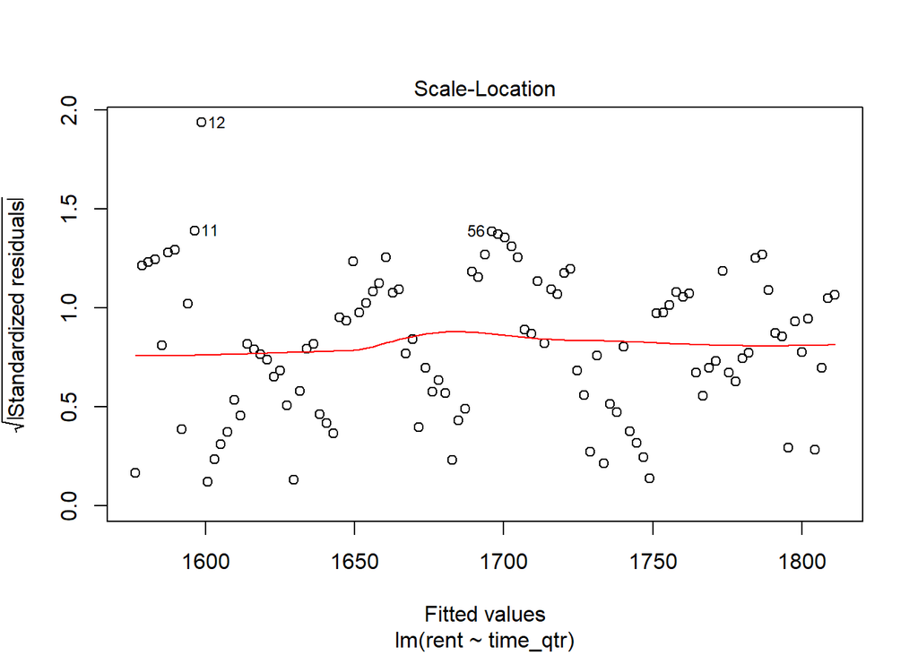

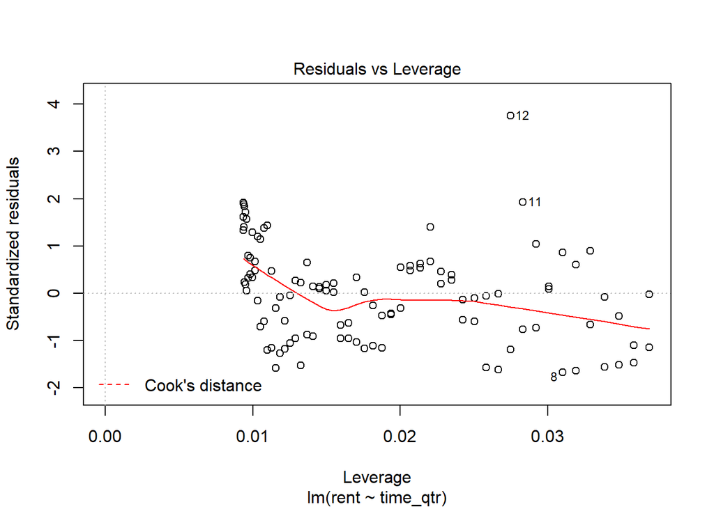

```r
chicago_lm <-lm(rent~time_qtr, data = chicago_ts)
plot(chicago_lm)
```

```r
summary(chicago_lm)
```

```
##
## Call:
## lm(formula = rent ~ time_qtr, data = chicago_ts)
##
## Residuals:
##     Min      1Q  Median      3Q     Max
## -89.738 -40.107   1.021  30.404 201.415
##
## Coefficients:
##              Estimate Std. Error t value Pr(>|t|)
## (Intercept) 1572.0444    10.7476  146.27   <2e-16 ***
## time_qtr       2.2117     0.1704   12.98   <2e-16 ***
## ---
## Signif. codes:  0 '***' 0.001 '**' 0.01 '*' 0.05 '.' 0.1 ' ' 1
##
## Residual standard error: 54.44 on 105 degrees of freedom
##   (1 observation deleted due to missingness)
## Multiple R-squared:  0.6161, Adjusted R-squared:  0.6124
## F-statistic: 168.5 on 1 and 105 DF,  p-value: < 2.2e-16
```

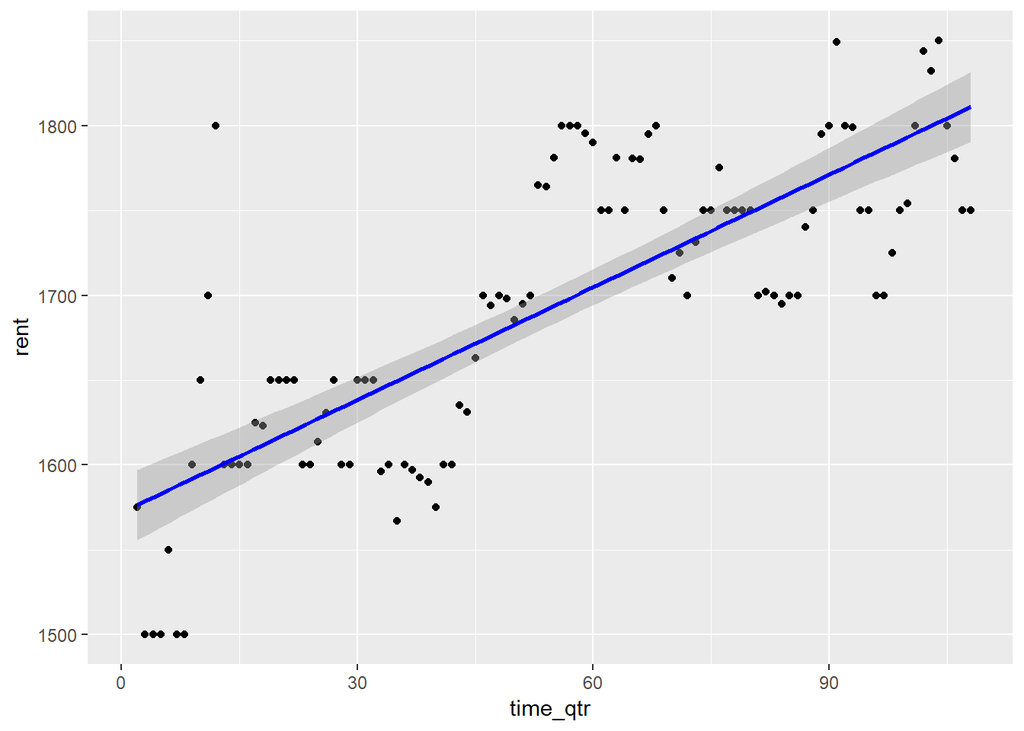

```r
ggplot(chicago_ts, aes(x = time_qtr, y = rent)) + geom_point()+
stat_smooth(method = "lm", col = "blue")
```